# Avaliação de intervenções na operação do BUZUFBA

Comparação de acessibilidade e exploração dos tempos de espera entre cenários

Autor

Gabriel Cury

Data de Publicação

19 de outubro de 2026

# 1 Resumo

Este relatório documenta um estudo exploratório de intervenções na rede de transporte do BUZUFBA, com foco na acessibilidade entre unidades da Universidade Federal da Bahia (UFBA). O trabalho parte de uma representação programática do sistema existente — GTFS, edificações, rede viária e elevação — e compara seis configurações de itinerários, sempre combinadas com a mesma intervenção locacional nas edificações.

A intervenção locacional consistiu em reposicionar, no modelo geográfico, a edificação associada à Faculdade de Economia para a região do Canela, no lugar anteriormente representado pela Faculdade de Educação, e reposicionar a Faculdade de Educação em Ondina, próximo ao estacionamento do Instituto de Matemática. A rede viária e a elevação do terreno foram mantidas. Em seguida, foram testadas substituições dos itinerários atribuídos às linhas B3 e B4 por itinerários já existentes no sistema, sem propor uma nova linha.

**Principal resultado:** entre os seis cenários avaliados, a configuração **B4 → B1 e B3 → B5** foi identificada na leitura comparativa como a alternativa mais equilibrada. Os gráficos mostram melhorias amplas na acessibilidade em 15 e 30 minutos, com um trade-off pequeno observado na Residência Universitária R1. Esse resultado a torna a candidata prioritária para uma rodada seguinte de testes — não uma comprovação de desempenho operacional em campo.

A análise de tempo de espera foi mantida como evidência exploratória. Seu gráfico não apresenta pontos para todos os fluxos em todos os cenários, pois a função considera apenas observações com transporte público (`n_rides > 0`). **Ponto ausente não significa espera igual a zero**: significa que não houve observação elegível para calcular a proporção de espera naquele cenário.

## 1.1 Principais mensagens

- A comparação foi feita com dois indicadores de acessibilidade: percentual de outras unidades alcançáveis em até 15 minutos e em até 30 minutos.
- Todas as seis combinações de itinerários apresentaram ganhos em parte das unidades, mas com trade-offs distintos; a magnitude e a distribuição desses efeitos variam entre edifícios.
- **B4 → B1 e B3 → B5** foi a combinação que apresentou o padrão visual mais favorável e menos perdas aparentes.
- Os resultados são simulações para uma data, um horário inicial e uma janela de partidas específicos. Não substituem validação com tempos observados, demanda real, lotação, custos, disponibilidade de frota ou condições de operação.

# 2 Contexto e objetivo

O estudo foi desenvolvido para transformar informações operacionais do BUZUFBA em uma rede analisável e, em seguida, usar essa representação para testar intervenções. O fluxo de trabalho adotado foi:

1. construir programaticamente os dados GTFS do sistema de ônibus;
2. organizar as edificações em arquivos GeoPackage, com uma representação geográfica para cada unidade;
3. integrar os dados de transporte com a rede viária PBF e o arquivo de elevação TIF por meio do pacote `r5r` no R;
4. calcular tempos de viagem entre as unidades e produzir gráficos que comparam o cenário de referência ao cenário com intervenção;
5. repetir a comparação para seis combinações de itinerário.

O objetivo desta etapa foi verificar como a realocação espacial das duas unidades e a reatribuição de itinerários da B3 e B4 afetam a acessibilidade potencial às demais unidades da UFBA. A análise também explorou a parcela do tempo total da viagem consumida pela espera em seis fluxos direcionais prioritários.

# 3 Rede de referência: linhas do BUZUFBA

O documento de itinerários fornecido para o estudo apresenta cinco linhas existentes. Os comprimentos e intervalos abaixo são extraídos do PDF fornecido pela Pró-Reitoria de Ações Afirmativas e Assistência Estudantil (PROAE) da UFBA; os intervalos são a diferença nominal entre os horários de partida listados, não uma medição de regularidade em cada parada.

| Linha | Extensão indicada | Intervalo nominal aproximado | Elementos relevantes do itinerário divulgado |
| --- | --- | --- | --- |
| B1 | 17 km | 90 min | São Lázaro, Politécnica, Arquitetura, Residência 5, Canela, ICS e Odontologia; o retorno inclui Reitoria, Canela, Graça, Direito, Faced, PAF 1 e PROAE. |
| B2 | 23 km | 100 min | Circuito amplo por PAF 1, Garibaldi, PROAE, Politécnica, São Lázaro, Canela, Reitoria, Belas Artes, Graça e Vitória, com variações de paradas na volta. |
| B3 | 13 km | 70 min | PAF 1, Garibaldi, Canela, Avenida 7 de Setembro/Faculdade de Economia e Belas Artes; a volta passa por Reitoria, Canela, Politécnica, Arquitetura e Geociências. |
| B4 | 14 km | 95 min | PAF 1, Garibaldi, PROAE, Politécnica, Canela e Reitoria, com trecho da Faculdade de Economia/Piedade e retorno via Vitória, Graça, Politécnica, São Lázaro, Arquitetura e Geociências. |
| B5 | 17 km | 95 min | Geociências, Facom, Portaria Principal, Centro de Esportes, Garibaldi, PROAE, São Lázaro, Politécnica, Canela e Reitoria; o retorno contempla também Vitória, Direito, ICS e Odontologia. |

As linhas B3 e B4 são especialmente relevantes para este experimento porque seus itinerários divulgados incluem a região da Piedade/Faculdade de Economia. O estudo compara essas duas linhas com padrões de itinerário que já existem — B1, B2 e B5 — para testar a redistribuição de cobertura entre Ondina, Engenharia, Canela, Arquitetura e outras unidades.

O PDF de itinerários usado como referência foi incluído no pacote do relatório em `insumos/rota_buzufba_2026.pdf`.

# 4 Intervenções testadas

## 4.1 Intervenção locacional

Nos arquivos de edificações do cenário de intervenção, foram reposicionadas duas feições:

- **Faculdade de Economia:** a representação geográfica foi deslocada para a região do Canela, ocupando a posição anteriormente atribuída à Faculdade de Educação.
- **Faculdade de Educação (Faced):** a representação geográfica foi deslocada para Ondina, próximo ao estacionamento do Instituto de Matemática.

Essa alteração é uma hipótese espacial para a simulação. Ela não significa que as edificações físicas tenham sido efetivamente transferidas. Como a análise usa pontos representativos derivados dos polígonos, a mudança de posição modifica os pontos de origem e destino usados no cálculo dos tempos de viagem.

## 4.2 Intervenção operacional

Não foram propostas novas linhas. Em cada cenário, o itinerário associado à B3 e/ou à B4 foi substituído por um padrão de itinerário já existente no sistema. Os seis cenários analisados foram:

| Código do cenário | Alteração aplicada às linhas | Descrição |
| --- | --- | --- |
| 1 | B3 → B1; B4 → B1 | As duas linhas passam a seguir o itinerário de referência da B1. |
| 2 | B3 → B2; B4 → B2 | As duas linhas passam a seguir o itinerário de referência da B2. |
| 3 | B3 → B5; B4 → B5 | As duas linhas passam a seguir o itinerário de referência da B5. |
| 4 | B3 → B2; B4 → B1 | A B3 adota o padrão B2 e a B4 adota o padrão B1. |
| 5 | **B3 → B5; B4 → B1** | **A B3 adota o padrão B5 e a B4 adota o padrão B1.** |
| 6 | B3 → B5; B4 → B2 | A B3 adota o padrão B5 e a B4 adota o padrão B2. |

Em todos os casos, a mudança de itinerário foi avaliada em conjunto com a intervenção locacional descrita acima. Portanto, os gráficos não isolam o efeito puro da mudança de rota do efeito da realocação geográfica das edificações: eles representam o efeito combinado das duas intervenções em relação ao cenário atual.

# 5 Metodologia

## 5.1 Fontes e preparação dos dados

A análise combina quatro componentes principais:

- **GTFS:** representação do serviço de ônibus e dos seus horários, criada programaticamente em R e alterada para reproduzir os cenários operacionais;
- **GeoPackages de edificações:** um arquivo para o cenário atual e outro para a intervenção, com as mesmas unidades identificadas pelo campo `name`, mas com geometrias diferentes onde a intervenção foi aplicada;
- **PBF de rede viária:** mantido igual entre os cenários;
- **TIF de elevação:** mantido igual entre os cenários.

O script de comparação reconstrói/carrega separadamente uma rede R5 para cada pasta de cenário. Assim, cada GTFS é avaliado na sua própria rede, enquanto a rede viária e a elevação permanecem constantes. O arquivo R utilizado nesta etapa está incluído em `insumos/analise_comparacao_cenarios_ufba.R`.

## 5.2 Indicadores de acessibilidade

Os tempos de viagem foram calculados entre os pontos representativos de todas as unidades, usando caminhada e transporte público (`WALK` e `TRANSIT`). Os parâmetros de simulação registrados no script foram:

| Parâmetro | Valor utilizado |
| --- | --- |
| Data e horário inicial | 13/10/2026, às 08h50 (fuso `America/Bahia`) |
| Janela de partidas | 60 minutos |
| Percentil de tempo de viagem | 50 (mediana) |
| Modos | Caminhada + transporte público |
| `max_rides` | 1, conforme configurado no script |
| Duração máxima na matriz de acessibilidade | 31 minutos, para incluir viagens de até 30 minutos |

Para cada unidade de origem, o indicador corresponde ao percentual de **outras unidades** que podem ser alcançadas dentro do limite de tempo. A própria unidade de origem é excluída da contagem e cada unidade-destino recebe peso igual.

Foram avaliados dois limites: **15 minutos** e **30 minutos**. Nos gráficos, o ponto claro representa o cenário atual, o ponto escuro representa a intervenção e a linha liga os dois valores para cada unidade. Um deslocamento para a direita indica maior percentual de unidades alcançáveis; um deslocamento para a esquerda indica redução; pontos próximos indicam pouca alteração visual.

Esse indicador mede acessibilidade entre unidades físicas representadas no arquivo, e não acesso ponderado por população, estudantes, empregos, capacidade de salas ou quantidade de serviços. A localização dos pontos representativos e o conjunto de unidades presentes no GeoPackage influenciam o resultado.

## 5.3 Indicador exploratório de tempo de espera

Além da matriz simples de tempos de viagem, o script usa `expanded_travel_time_matrix()` com `breakdown = TRUE` para estimar componentes das viagens. Foram selecionados quatro pontos representativos: PAF I para Ondina, Escola Politécnica para Engenharia, PAC para Canela e a unidade de Arquitetura para a região de Arquitetura. Os seis fluxos direcionais analisados são:

- Ondina → Engenharia e Engenharia → Ondina;
- Ondina → Canela e Canela → Ondina;
- Ondina → Arquitetura e Arquitetura → Ondina.

Para cada partida simulada com transporte público, calcula-se a proporção `wait_time / total_time × 100`; em seguida, o gráfico usa a mediana das proporções. Essa análise é exploratória, pois o filtro `n_rides > 0` exclui viagens sem embarque em transporte público. Por isso, **um ponto ausente no gráfico não representa 0% de espera**; representa a falta de observações que atendam aos critérios de cálculo naquele cenário.

# 6 Síntese comparativa dos cenários

A leitura dos gráficos é qualitativa. O ZIP contém os PNGs comparativos, mas não inclui uma tabela numérica por unidade com os valores brutos e as diferenças em pontos percentuais. Assim, o relatório não afirma contagens exatas de unidades melhoradas nem médias gerais de ganho que não possam ser verificadas diretamente a partir de uma tabela de dados.

[output not shown]

A seguir, os painéis mantêm os gráficos originais gerados para cada cenário. Os dois gráficos de acessibilidade devem ser lidos conjuntamente: o limite de 15 minutos destaca acessos próximos e mais sensíveis à localização e ao itinerário; o limite de 30 minutos incorpora um conjunto mais amplo de destinos potencialmente acessíveis. Os gráficos de espera complementam essa leitura, mas possuem ausências de dados em alguns fluxos e, portanto, não permitem uma comparação completa em todas as direções.

# 7 Gráficos completos por cenário

## 7.1 B3 e B4 passam a seguir B1

**Configuração:** B3 → B1 e B4 → B1, junto com a realocação espacial da Faculdade de Economia para Canela e da Faced para Ondina.

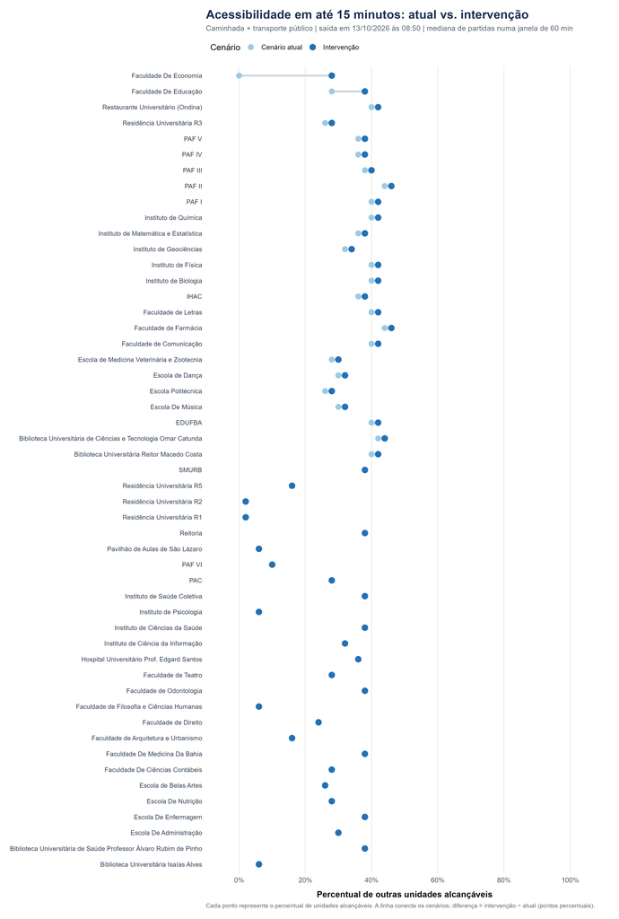

Figura 1: Acessibilidade em até 15 minutos — B3 e B4 → B1.

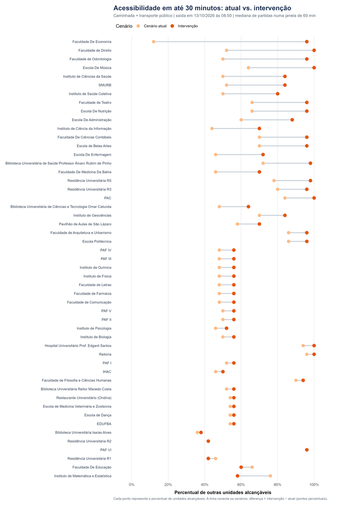

Figura 2: Acessibilidade em até 30 minutos — B3 e B4 → B1.

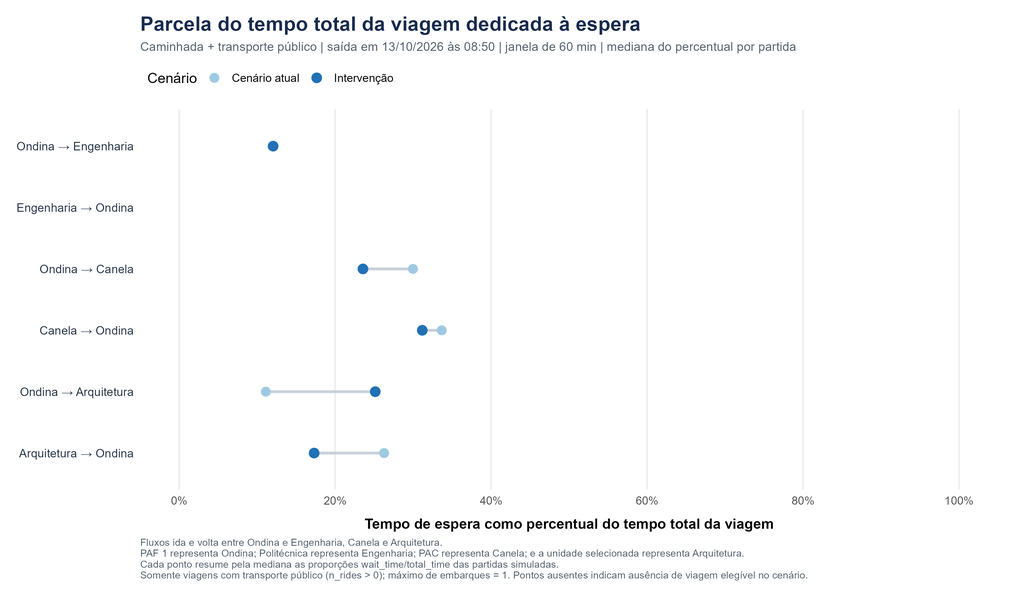

Figura 3: Tempo de espera nos fluxos direcionais — B3 e B4 → B1.

## 7.2 B3 e B4 passam a seguir B2

**Configuração:** B3 → B2 e B4 → B2, junto com a realocação espacial das duas edificações.

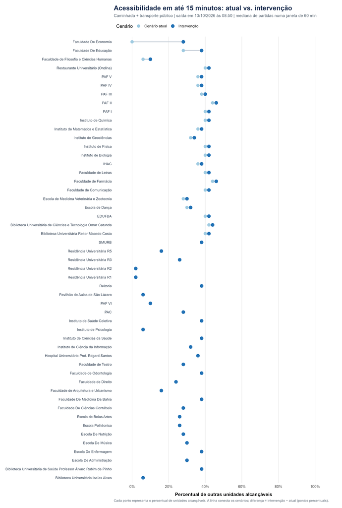

Figura 4: Acessibilidade em até 15 minutos — B3 e B4 → B2.

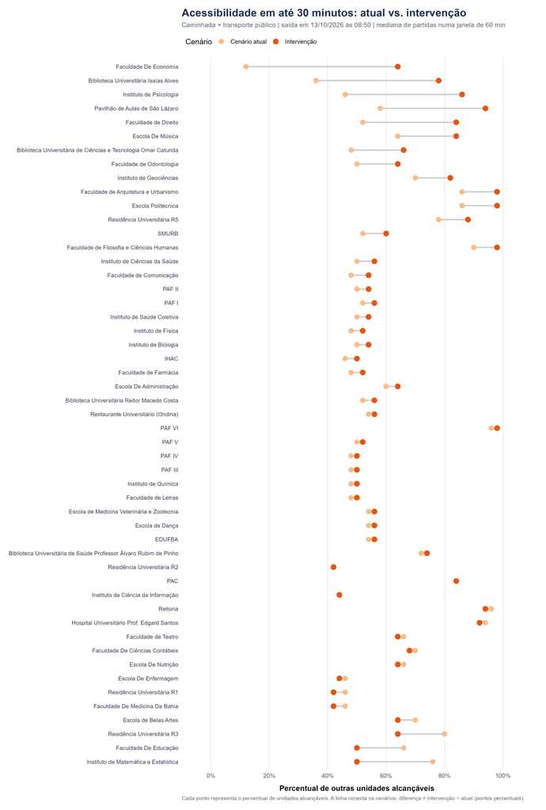

Figura 5: Acessibilidade em até 30 minutos — B3 e B4 → B2.

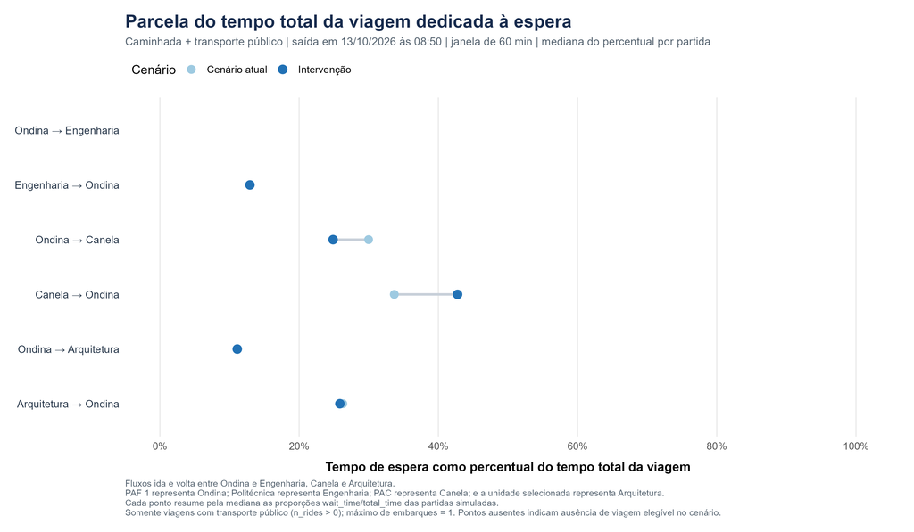

Figura 6: Tempo de espera nos fluxos direcionais — B3 e B4 → B2.

## 7.3 B3 e B4 passam a seguir B5

**Configuração:** B3 → B5 e B4 → B5, junto com a realocação espacial das duas edificações.

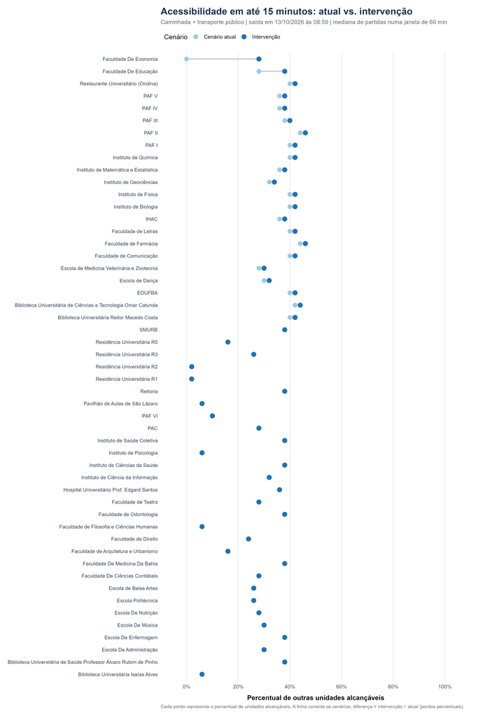

Figura 7: Acessibilidade em até 15 minutos — B3 e B4 → B5.

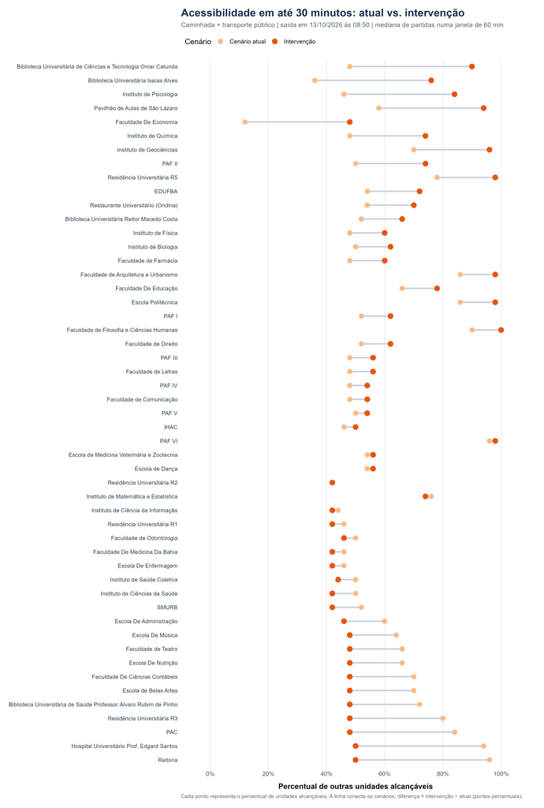

Figura 8: Acessibilidade em até 30 minutos — B3 e B4 → B5.

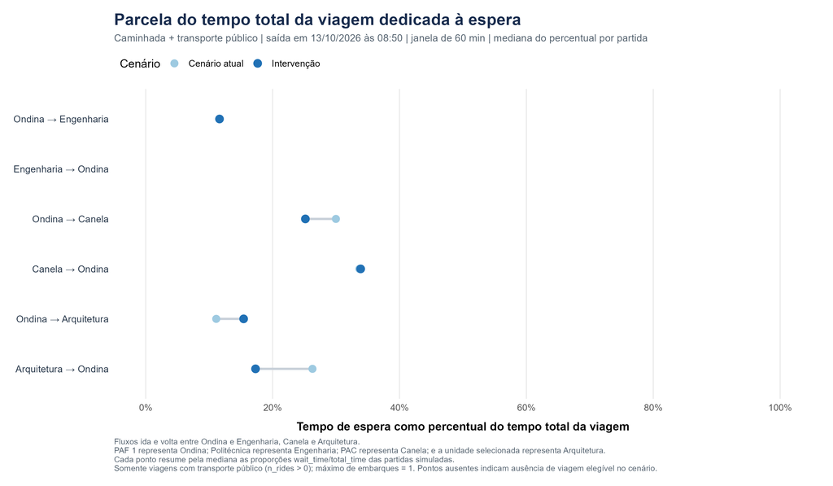

Figura 9: Tempo de espera nos fluxos direcionais — B3 e B4 → B5.

## 7.4 B3 passa a seguir B2 e B4 passa a seguir B1

**Configuração:** B3 → B2 e B4 → B1, junto com a realocação espacial das duas edificações.

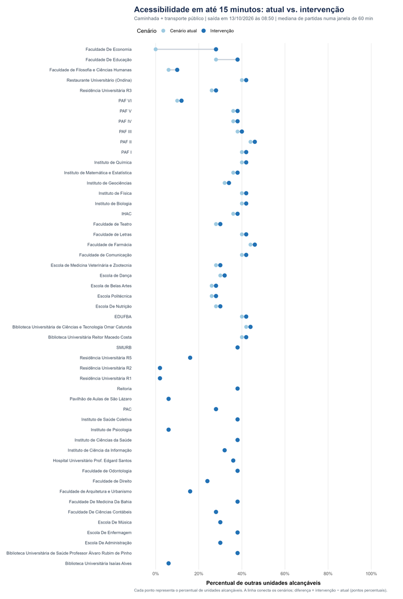

Figura 10: Acessibilidade em até 15 minutos — B3 → B2 e B4 → B1.

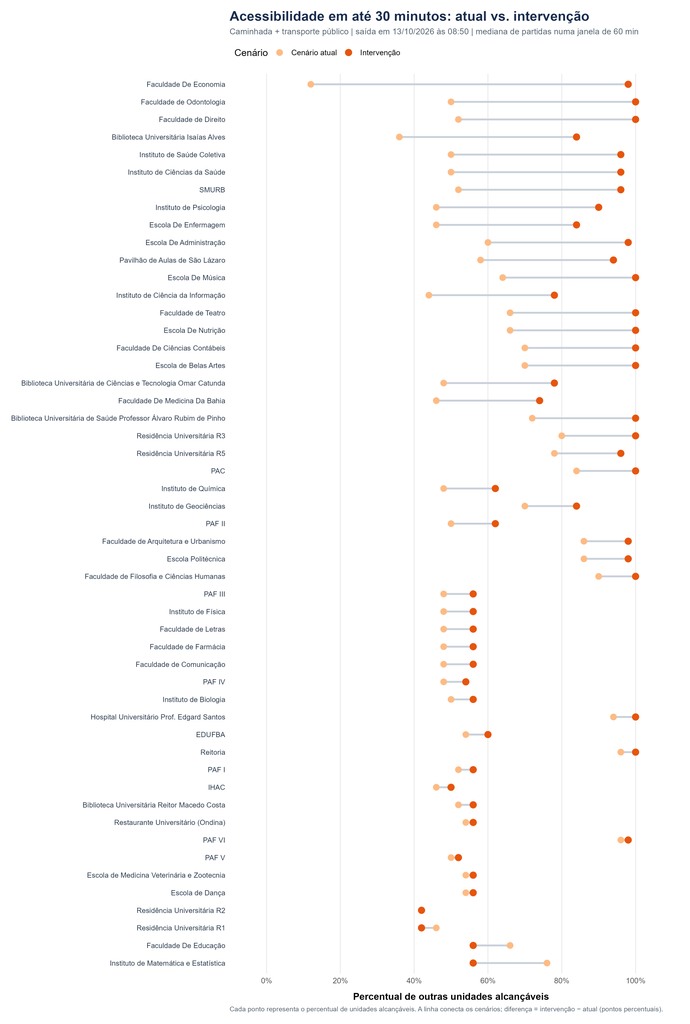

Figura 11: Acessibilidade em até 30 minutos — B3 → B2 e B4 → B1.

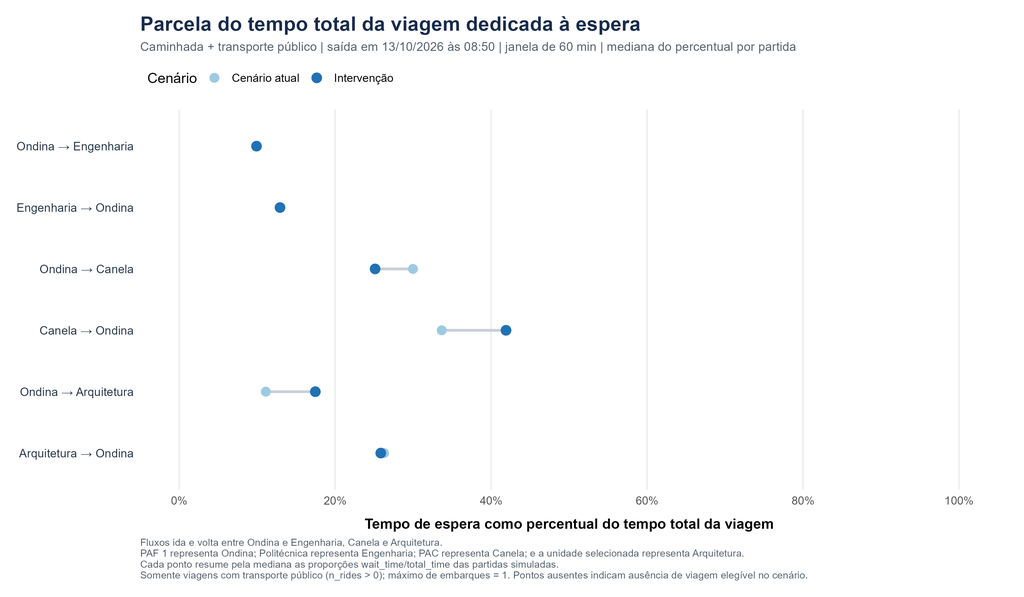

Figura 12: Tempo de espera nos fluxos direcionais — B3 → B2 e B4 → B1.

## 7.5 B4 passa a seguir B1 e B3 passa a seguir B5 — cenário prioritário

**Configuração:** B4 → B1 e B3 → B5, junto com a realocação espacial das duas edificações.

Esta foi a combinação considerada mais promissora no estudo. A leitura dos gráficos de acessibilidade indica que os ganhos se distribuem de forma ampla entre as unidades, tanto no limite de 15 minutos quanto no de 30 minutos. A principal ressalva registrada foi uma pequena piora para a Residência Universitária R1. Esse trade-off deve permanecer documentado, mesmo quando a diferença visual é pequena.

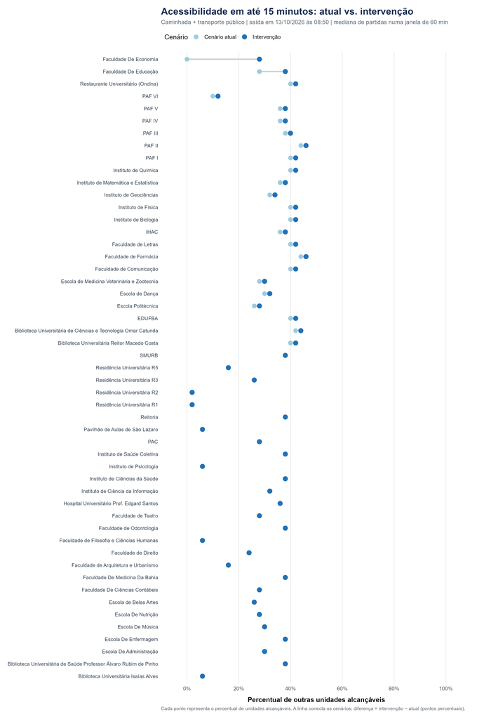

Figura 13: Acessibilidade em até 15 minutos — B4 → B1 e B3 → B5.

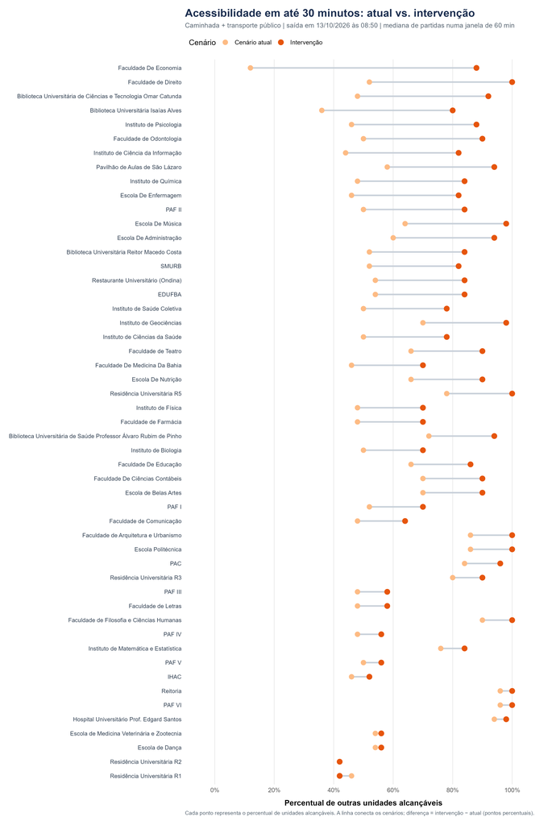

Figura 14: Acessibilidade em até 30 minutos — B4 → B1 e B3 → B5.

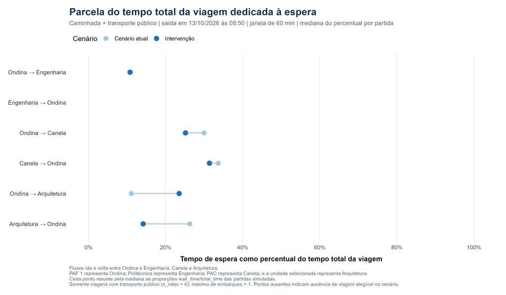

Figura 15: Tempo de espera nos fluxos direcionais — B4 → B1 e B3 → B5.

## 7.6 B4 passa a seguir B2 e B3 passa a seguir B5

**Configuração:** B4 → B2 e B3 → B5, junto com a realocação espacial das duas edificações.

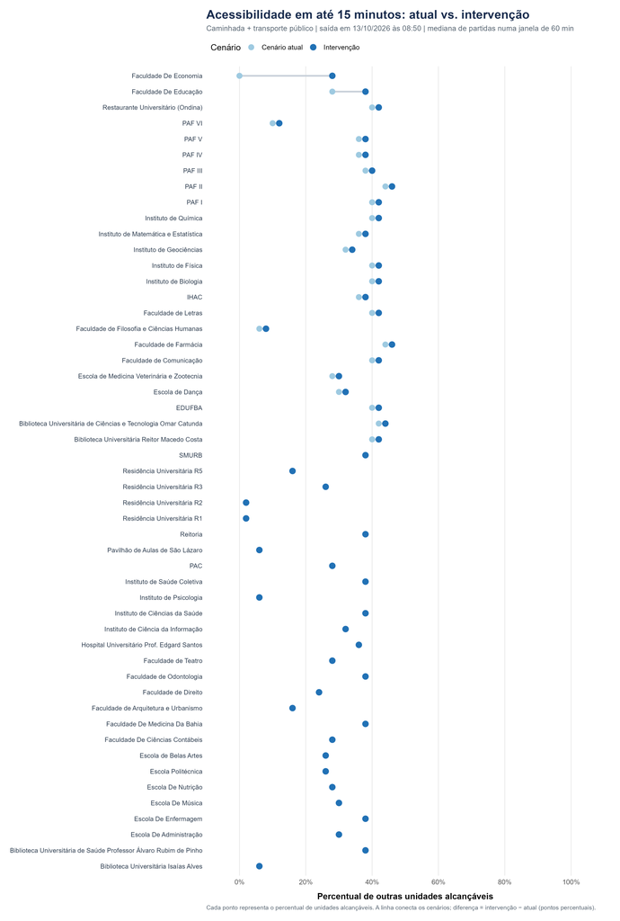

Figura 16: Acessibilidade em até 15 minutos — B4 → B2 e B3 → B5.

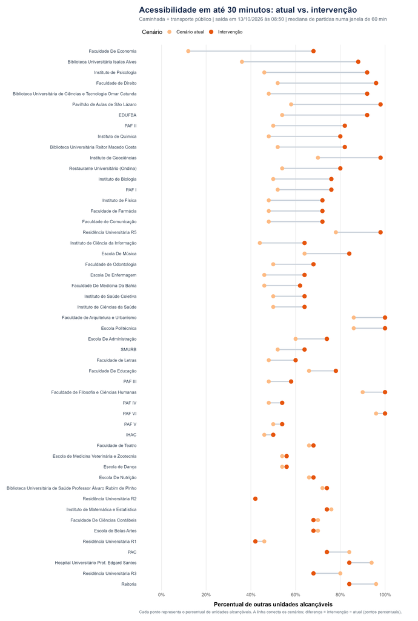

Figura 17: Acessibilidade em até 30 minutos — B4 → B2 e B3 → B5.

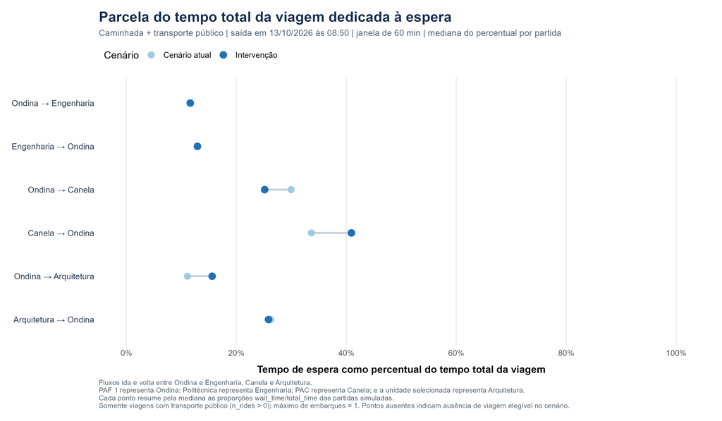

Figura 18: Tempo de espera nos fluxos direcionais — B4 → B2 e B3 → B5.

# 8 Discussão

## 8.1 Por que B4 → B1 e B3 → B5 se destaca

A configuração selecionada combina dois padrões de atendimento com características complementares descritas no itinerário de referência:

- **B3 → B5:** incorpora o padrão que cobre diretamente pontos de Ondina — Geociências, Facom, Portaria Principal e Centro de Esportes — e continua por Garibaldi, PROAE, São Lázaro, Politécnica, Canela e Reitoria;
- **B4 → B1:** incorpora um padrão que conecta São Lázaro, Politécnica, Arquitetura, Residência 5 e Canela e inclui, no retorno, paradas em Canela, Graça, Direito, Faced, PAF 1 e PROAE.

Essa interpretação é coerente com os fluxos investigados e com o resultado visual do cenário. A B5 oferece uma ligação explícita entre pontos de Ondina e os eixos de Engenharia/Canela, enquanto a B1 mantém cobertura de outras unidades do campus. O resultado sugere que a combinação é mais equilibrada do que atribuir o mesmo padrão amplo às duas linhas ou utilizar a B2 em uma delas.

O efeito observado, entretanto, resulta do **conjunto da mudança locacional e da mudança dos itinerários**. Uma rodada futura deve testar cada intervenção separadamente para identificar quanto do ganho é produzido pela nova localização das edificações e quanto vem da operação das linhas.

## 8.2 Trade-offs e equidade espacial

Os gráficos mostram que uma melhoria agregada não garante ganhos idênticos para todas as unidades. A Residência Universitária R1 aparece como o trade-off destacado no cenário prioritário, com uma redução pequena no indicador em relação ao cenário atual. Esse resultado merece acompanhamento porque unidades residenciais podem representar necessidades de acesso diferentes das unidades acadêmicas.

Nas outras combinações, também há efeitos heterogêneos: determinados pontos ganham acessibilidade e outros mantêm valores semelhantes ou apresentam redução. Para fundamentar uma decisão, não basta escolher o cenário cuja maioria dos pontos se desloca para a direita. Também é importante identificar as unidades que perdem acesso, quantificar a magnitude da perda e avaliar se existem alternativas para preservar o atendimento.

## 8.3 Como interpretar os gráficos de espera

Os gráficos de espera são complementares, não conclusivos. O percentual é calculado apenas para observações em que o resultado da matriz expandida indica transporte público e em que `wait_time` e `total_time` são válidos. Em alguns fluxos, principalmente Ondina–Engenharia, não houve observações suficientes com transporte público nos dois cenários para traçar ambos os pontos. Isso pode refletir a forma como o GTFS e os pontos representativos se conectam à rede no horário simulado.

Por essa razão, não seria correto concluir que a espera foi reduzida quando existe apenas um ponto no gráfico. Antes de usar espera como critério de seleção, recomenda-se verificar a disponibilidade de viagens elegíveis por fluxo e cenário e ampliar a análise para mais horários ou janelas representativas. Na configuração atual, o indicador de acessibilidade é a base mais consistente para a comparação visual entre as seis alternativas.

# 9 Limitações do estudo

1. **Janela temporal limitada.** Os cálculos refletem saídas iniciadas a partir de 13/10/2026 às 08h50, numa janela de 60 minutos. A ordem dos cenários pode mudar em outros períodos do dia ou dias da semana.
2. **Indicador não ponderado por demanda.** Cada unidade conta como um destino de peso igual; a análise não incorpora o número de pessoas, viagens, vagas, serviços ou empregos em cada unidade.
3. **Parâmetro de embarques restritivo.** O script utiliza `max_rides = 1`; itinerários que necessitem de mais embarques/trechos de transporte público podem não aparecer como viáveis, conforme a interpretação do parâmetro pelo R5.
4. **Pontos representativos.** Os tempos são calculados entre pontos representativos dos polígonos, e não necessariamente entre portas de acesso, plataformas ou pontos reais de embarque.
5. **Tempo de espera incompleto em alguns fluxos.** As observações sem transporte público são excluídas do indicador de espera; pontos ausentes não podem ser tratados como zero.
6. **Resultados majoritariamente visuais.** O pacote fornecido contém os PNGs, não uma tabela completa com os indicadores por unidade para cada cenário. As conclusões comparativas neste documento são qualitativas; para publicar variações precisas em pontos percentuais, deve-se exportar e comparar as matrizes/indicadores numéricos.
7. **Não há validação operacional de campo.** A simulação não estabelece, por si só, a viabilidade de cumprir tempos de percurso, ciclos de veículos, intervalos, lotação, custos de operação ou a preferência dos usuários.

# 10 Próximos passos recomendados

1. **Priorizar B4 → B1 e B3 → B5** para uma análise aprofundada, mantendo documentada a pequena perda indicada para a Residência Universitária R1.
2. **Isolar os efeitos das intervenções:** comparar (a) somente a mudança das edificações, (b) somente a mudança dos itinerários e (c) a combinação das duas mudanças. Isso permitirá separar os efeitos espaciais dos operacionais.
3. **Calcular resultados numéricos por cenário:** armazenar indicadores de cada unidade e produzir uma tabela comparativa com diferença em pontos percentuais, número de unidades melhoradas, inalteradas e pioradas, além das maiores perdas e ganhos.
4. **Testar horários representativos:** repetir a análise em diferentes períodos de partida e em mais dias cobertos pelo GTFS, evitando concluir com base em uma única janela.
5. **Aprofundar a espera:** analisar mais janelas de partida e verificar explicitamente o número de observações elegíveis para cada fluxo e cenário; não interpretar fluxos sem observações como espera zero.
6. **Validar viabilidade operacional:** confrontar itinerários promissores com duração real de percurso, tempo de retorno dos veículos, sobreposição de linhas e cobertura das paradas.

# 11 Conclusão

O estudo transformou a representação digital do BUZUFBA em uma base para experimentos controlados de itinerário e localização. As seis combinações avaliadas sugerem que mudanças nas rotas existentes, quando combinadas com o reposicionamento das edificações usadas no cenário de intervenção, podem alterar de maneira importante o percentual de unidades acessíveis em 15 e 30 minutos.

Entre as alternativas analisadas, **B4 → B1 e B3 → B5 é a recomendação prioritária para investigação adicional**, porque apresentou o padrão mais favorável e equilibrado na comparação visual, com uma perda pequena identificada na Residência Universitária R1. A próxima etapa deve preservar essa alternativa como candidata, mas acrescentar resultados numéricos por unidade, testar diferentes horários e separar os efeitos da mudança locacional e da mudança operacional antes de fazer recomendações finais.

## 11.1 Materiais incluídos no pacote

- `relatorio_estudo_buzufba.qmd`: este relatório em Quarto Markdown;
- `figuras/`: os 18 gráficos originais organizados por cenário;
- `insumos/rota_buzufba_2026.pdf`: PDF com os itinerários de referência;
- `insumos/analise_comparacao_cenarios_ufba.R`: script de comparação usado como referência metodológica.

Os dados GTFS, PBF, TIF e GeoPackages não estão incluídos no pacote. O relatório utiliza os gráficos prontos e não precisa executar novamente a análise para ser renderizado em HTML.